# Group Assignment

Zhicong Hu

12/03/2022

# Get data

We extract price data of XOM and CVX, from 2018/01/01 to 2020/12/31.

```r
data <- tq_get(c("XOM","CVX"), get = "stock.prices", from = "2018-01-01", to = "2020-12-31") %>%
  dplyr::select(symbol, date, close) %>%
  mutate(close = round(close, 2))
```

# Visualization

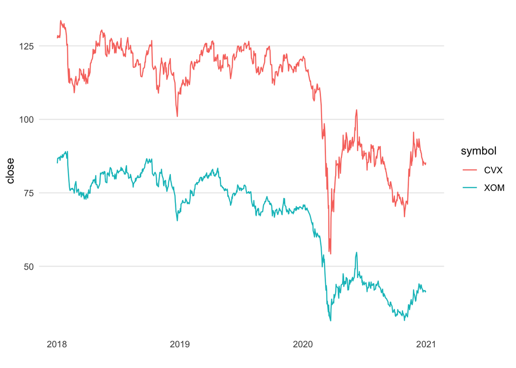

```r
ggplot(data, aes(x = date, y = close, color = symbol)) +
  geom_line() +
  theme_minimal() +
  theme(panel.grid.minor.x =  element_blank(), panel.grid.major.x =  element_blank(),
        panel.grid.minor.y =  element_blank()) +
  labs(x = "")
```

# Data Formatting

```r
data <- data %>%
  pivot_wider(names_from = symbol, values_from = close)
```

# Modelling

```r
data <- data %>%
  mutate(spread = XOM-CVX)
```

## Test for stationary

We tested for stationary with the Dickey-Fuller Test for both Exxon Mobil and Chevron’s stock price and both are not stationary. Therefore, we can say that stock prices of them are random walks.

```r
adf.test(data$CVX)
```

```
##
##  Augmented Dickey-Fuller Test
##
## data:  data$CVX
## Dickey-Fuller = -2.9175, Lag order = 9, p-value = 0.1899
## alternative hypothesis: stationary
```

```r
adf.test(data$XOM)
```

```
##
##  Augmented Dickey-Fuller Test
##
## data:  data$XOM
## Dickey-Fuller = -2.2453, Lag order = 9, p-value = 0.4745
## alternative hypothesis: stationary
```

```r
adf.test(data$CVX-data$XOM)
```

```
##
##  Augmented Dickey-Fuller Test
##
## data:  data$CVX - data$XOM
## Dickey-Fuller = -4.0943, Lag order = 9, p-value = 0.01
## alternative hypothesis: stationary
```

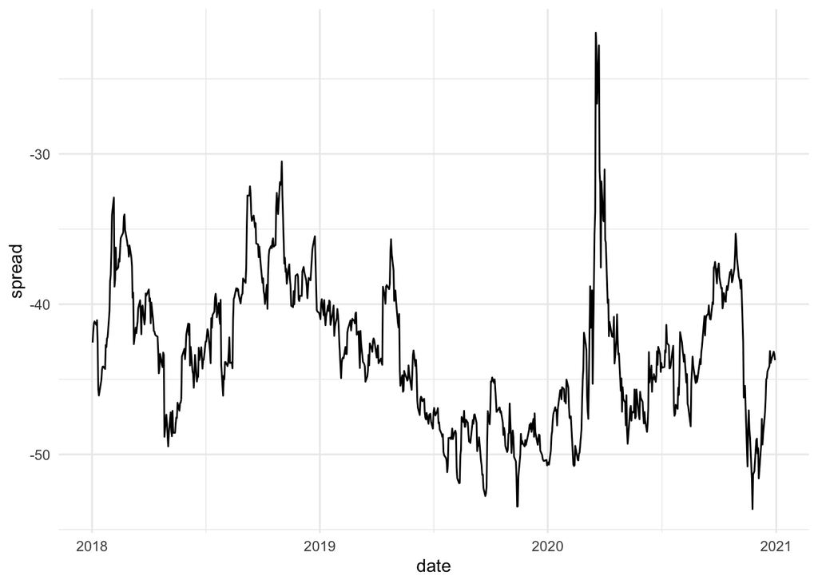

```r
ggplot(data, aes(x = date, y = spread)) +
  geom_line() +
  theme_minimal() +
  theme(legend.position = "none")
```

## VAR

###Individual

We use AIC to select the lag we want to include for prediction.

```r
df <- data %>% dplyr::select(CVX, XOM)

VARselect(df, lag.max = 10, type = "const")
```

```
## $selection
## AIC(n)  HQ(n)  SC(n) FPE(n)
##      8      1      1      8
##
## $criteria
##                1         2         3         4         5         6         7
## AIC(n) 0.7997661 0.7902677 0.7901957 0.7898609 0.7927629 0.7999255 0.7958589
## HQ(n)  0.8140871 0.8141361 0.8236114 0.8328239 0.8452732 0.8619832 0.8674639
## SC(n)  0.8369209 0.8521924 0.8768902 0.9013252 0.9289971 0.9609295 0.9816327
## FPE(n) 2.2250206 2.2039873 2.2038301 2.2030951 2.2095021 2.2253909 2.2163678
##                8         9        10
## AIC(n) 0.7519071 0.7586592 0.7585324
## HQ(n)  0.8330594 0.8493588 0.8587794
## SC(n)  0.9624508 0.9939727 1.0186158
## FPE(n) 2.1210747 2.1354583 2.1352042
```

Therefore, we select lag length p = 8 for VAR since it has the lowest AIC.

Now, we run the simple VAR model without error correction term.

```r
var.model <- VAR(df, p = 8, type = "const")
summary(var.model)
```

```
##
## VAR Estimation Results:
## =========================
## Endogenous variables: CVX, XOM
## Deterministic variables: const
## Sample size: 747
## Log Likelihood: -2365.189
## Roots of the characteristic polynomial:
## 0.9982 0.9493 0.8601 0.8601 0.7733 0.7733 0.7724 0.7724 0.6978 0.6813 0.6327 0.6327 0.5844 0.5386 0.5386 0.002311
## Call:
## VAR(y = df, p = 8, type = "const")
##
##
## Estimation results for equation CVX:
## ====================================
## CVX = CVX.l1 + XOM.l1 + CVX.l2 + XOM.l2 + CVX.l3 + XOM.l3 + CVX.l4 + XOM.l4 + CVX.l5 + XOM.l5 + CVX.l6 + XOM.l6 + CVX.l7 + XOM.l7 + CVX.l8 + XOM.l8 + const
##
##         Estimate Std. Error t value Pr(>|t|)
## CVX.l1  0.779445   0.060511  12.881  < 2e-16 ***
## XOM.l1  0.266399   0.113680   2.343 0.019375 *
## CVX.l2  0.272187   0.080823   3.368 0.000798 ***
## XOM.l2 -0.291551   0.160881  -1.812 0.070364 .
## CVX.l3 -0.138251   0.081322  -1.700 0.089547 .
## XOM.l3  0.159681   0.161212   0.991 0.322258
## CVX.l4 -0.082316   0.081524  -1.010 0.312965
## XOM.l4  0.168050   0.161919   1.038 0.299675
## CVX.l5  0.122567   0.081493   1.504 0.133009
## XOM.l5 -0.215683   0.161844  -1.333 0.183060
## CVX.l6 -0.135438   0.081212  -1.668 0.095799 .
## XOM.l6  0.095744   0.161291   0.594 0.552954
## CVX.l7  0.311346   0.080922   3.847 0.000130 ***
## XOM.l7 -0.125014   0.161127  -0.776 0.438077
## CVX.l8 -0.188065   0.060290  -3.119 0.001884 **
## XOM.l8 -0.004613   0.113646  -0.041 0.967633
## const   2.866493   0.814693   3.518 0.000461 ***
## ---
## Signif. codes:  0 '***' 0.001 '**' 0.01 '*' 0.05 '.' 0.1 ' ' 1
##
##
## Residual standard error: 2.099 on 730 degrees of freedom
```

[output cut: 30 more lines]

```
## Residual standard error: 1.138 on 730 degrees of freedom
## Multiple R-Squared: 0.9955,  Adjusted R-squared: 0.9954
## F-statistic: 1.007e+04 on 16 and 730 DF,  p-value: < 2.2e-16
##
##
##
## Covariance matrix of residuals:
##       CVX   XOM
## CVX 4.407 1.920
## XOM 1.920 1.294
##
## Correlation matrix of residuals:
##        CVX    XOM
## CVX 1.0000 0.8037
## XOM 0.8037 1.0000
```

With our model built, we compare our predicted prices with actual prices of between year 2021.

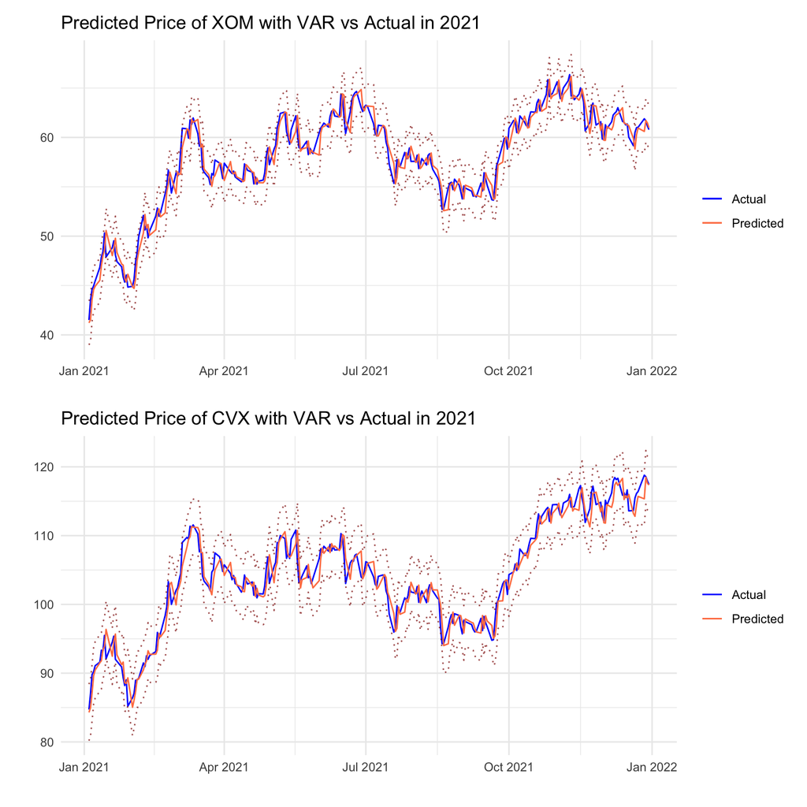

```r
future_data <- tq_get(c("CVX","XOM"), get = "stock.prices", from = "2020-12-21", to = "2021-12-31") %>%
  dplyr::select(symbol, date, close) %>%
  mutate(close = round(close, 2)) %>%
  pivot_wider(names_from = symbol, values_from = close)

var.pred <- data.frame(CVX_pre = NA, CVX_lower = NA, CVX_higher = NA,
                       XOM_pre = NA, XOM_lower = NA, XOM_higher = NA)
for (i in 1:(nrow(future_data)-8)) {
  temp_model <- VAR(rbind(df, future_data[8:(7+i),c("CVX","XOM")]), p = 8, type = "const")
  var.pred[i,"CVX_pre"] <- predict(temp_model, exoPred = NULL, n.ahead=1)$fcst$CVX[1]
  var.pred[i,"CVX_lower"] <- predict(temp_model, exoPred = NULL, n.ahead=1)$fcst$CVX[2]
  var.pred[i,"CVX_higher"] <- predict(temp_model, exoPred = NULL, n.ahead=1)$fcst$CVX[3]
  var.pred[i,"XOM_pre"] <- predict(temp_model, exoPred = NULL, n.ahead=1)$fcst$XOM[1]
  var.pred[i,"XOM_lower"] <- predict(temp_model, exoPred = NULL, n.ahead=1)$fcst$XOM[2]
  var.pred[i,"XOM_higher"] <- predict(temp_model, exoPred = NULL, n.ahead=1)$fcst$XOM[3]
}

(future_data[9:nrow(future_data),] %>%
  cbind(XOM_pre = var.pred$XOM_pre, XOM_lower = var.pred$XOM_lower, XOM_higher = var.pred$XOM_higher) %>%
  ggplot(aes(x = date)) +
    geom_line(aes(y = XOM, color = "Actual")) +
    geom_line(aes(y = XOM_pre, color = "Predicted")) +
    geom_line(aes(y = XOM_lower), color = "darkred", linetype = "dotted", alpha = 0.7) +
    geom_line(aes(y = XOM_higher), color = "darkred", linetype = "dotted", alpha = 0.7) +
    scale_color_manual("",
                       breaks = c("Actual","Predicted"),
                       values = c("blue","coral")) +
    theme_minimal() +
    labs(title = "Predicted Price of XOM with VAR vs Actual in 2021", x = "", y = "")) /
  (future_data[9:nrow(future_data),] %>%
  cbind(CVX_pre = var.pred$CVX_pre, CVX_lower = var.pred$CVX_lower, CVX_higher = var.pred$CVX_higher) %>%
  ggplot(aes(x = date)) +
    geom_line(aes(y = CVX, color = "Actual")) +
    geom_line(aes(y = CVX_pre, color = "Predicted")) +
    geom_line(aes(y = CVX_lower), color = "darkred", linetype = "dotted", alpha = 0.7) +
    geom_line(aes(y = CVX_higher), color = "darkred", linetype = "dotted", alpha = 0.7) +
    scale_color_manual("",
                       breaks = c("Actual","Predicted"),
                       values = c("blue","coral")) +
    theme_minimal() +
    labs(title = "Predicted Price of CVX with VAR vs Actual in 2021", x = "", y = ""))
```

### Spread

Now, we build VAR model for prediction of the spread.

```r
df.diff <- diff(as.matrix(df), lag = 1)
# estimation
vare_diff <- lineVar(df.diff, lag = 8, include = "const", model = "VAR")
vare_diff

varf_diff <- data.frame(CVX_pre = NA, XOM_pre = NA)
for (i in 1:(nrow(future_data)-8)) {
  varf_diff[i,"CVX_pre"] <- predict(vare_diff, newdata = future_data[i:(i+7),c("CVX","XOM")], exoPred = NULL,
                                   n.ahead=1)[1]
  varf_diff[i,"XOM_pre"] <- predict(vare_diff, newdata = future_data[i:(i+7),c("CVX","XOM")], exoPred = NULL,
                                   n.ahead=1)[2]
}
varf_diff$CVX_pre <- cumsum(varf_diff$CVX_pre) + future_data$CVX[8]
varf_diff$XOM_pre <- cumsum(varf_diff$XOM_pre) + future_data$XOM[8]


(tq_get(c("XOM"), get = "stock.prices", from = "2010-01-01", to = "2010-12-31") %>%
  dplyr::select(symbol, date, close) %>%
  mutate(close = round(close, 2)) %>%
  pivot_wider(names_from = symbol, values_from = close) %>%
  cbind(XOM_pre = df$XOM[nrow(df)] + cumsum(varf_diff$fcst$XOM[,1]),
        XOM_lower = df$XOM[nrow(df)] + cumsum(varf_diff$fcst$XOM[,1]) + varf_diff$fcst$XOM[,2],
        XOM_higher = df$XOM[nrow(df)] + cumsum(varf_diff$fcst$XOM[,1]) + varf_diff$fcst$XOM[,3]) %>%
  ggplot(aes(x = date)) +
    geom_line(aes(y = XOM, color = "Actual")) +
    geom_line(aes(y = XOM_pre, color = "Predicted")) +
    geom_line(aes(y = XOM_lower), color = "darkred", alpha = 0.7, linetype = "dotted") +
    geom_line(aes(y = XOM_higher), color = "darkred", alpha = 0.7, linetype = "dotted") +
    scale_color_manual("",
                       breaks = c("Actual","Predicted"),
                       values = c("darkgreen","darkblue")) +
    theme_minimal() +
    labs(title = "Predicted Price of XOM with VAR vs Actual in 2010", x = "", y = "")) /
  (tq_get(c("CVX"), get = "stock.prices", from = "2010-01-01", to = "2010-12-31") %>%
  dplyr::select(symbol, date, close) %>%
  mutate(close = round(close, 2)) %>%
  pivot_wider(names_from = symbol, values_from = close) %>%
  cbind(CVX_pre = df$CVX[nrow(df)] + cumsum(varf_diff$fcst$CVX[,1]),
        CVX_lower = df$CVX[nrow(df)] + cumsum(varf_diff$fcst$CVX[,1]) + varf_diff$fcst$CVX[,2],
        CVX_higher = df$CVX[nrow(df)] + cumsum(varf_diff$fcst$CVX[,1]) + varf_diff$fcst$CVX[,3]) %>%
  ggplot(aes(x = date)) +
    geom_line(aes(y = CVX, color = "Actual")) +
    geom_line(aes(y = CVX_pre, color = "Predicted")) +
    geom_line(aes(y = CVX_lower), color = "darkred", alpha = 0.7, linetype = "dotted") +
    geom_line(aes(y = CVX_higher), color = "darkred", alpha = 0.7, linetype = "dotted") +
    scale_color_manual("",
                       breaks = c("Actual","Predicted"),
                       values = c("darkgreen","darkblue")) +
    theme_minimal() +
    labs(title = "Predicted Price of CVX with VAR vs Actual in 2010", x = "", y = ""))
```

[output not shown]

## VECM

Showing that our VAR model does not work well with two random walks and that the spread of the two random walks are stationary, we can include the spread into our model to get a VECM model.

```r
#========================================================
# Cointegration Test
#========================================================

#———————————————-
# Johansen Cointegration Procedure
#———————————————-
# ecdet  = ‘none’  for no intercept
#          ‘const’ for constant term
#          ‘trend’ for trend variable
#          in cointegration
# type   =  eigen or trace test
# K      =  lag order of VAR
# spec   = "transitory" or "longrun"
# season = centered seasonal dummy (4:quarterly)
# dumvar = another dummy variables
#———————————————-

coint_ca.jo <- ca.jo(
    df, ecdet = "const", type  = "eigen", K = 8,
    spec = "transitory", season = NULL, dumvar = NULL)
summary(coint_ca.jo)
```

```
##
## ######################
## # Johansen-Procedure #
## ######################
##
## Test type: maximal eigenvalue statistic (lambda max) , without linear trend and constant in cointegration
##
## Eigenvalues (lambda):
## [1] 2.337871e-02 3.534824e-03 7.533572e-19
##
## Values of teststatistic and critical values of test:
##
##           test 10pct  5pct  1pct
## r <= 1 |  2.65  7.52  9.24 12.97
## r = 0  | 17.67 13.75 15.67 20.20
##
## Eigenvectors, normalised to first column:
## (These are the cointegration relations)
##
##               CVX.l1     XOM.l1 constant
## CVX.l1     1.0000000    1.00000  1.00000
## XOM.l1    -0.9364365   14.03974 -2.25308
## constant -47.9783475 -536.42565 50.29263
##
## Weights W:
## (This is the loading matrix)
##
##            CVX.l1        XOM.l1     constant
## CVX.d -0.05840737 -0.0001196891 1.350518e-16
## XOM.d -0.01341690 -0.0001125794 3.186265e-17
```

We can interpret our results of test-statistics and critical values. The test of r = 0, which has the null hypothesis that there is no presence of cointegration, we can reject with a level of significance of 5% but we are unable to reject the test of r <= 1. Therefore, we conclude that cointegration exist with a r = 1 or the rank of the matrix is 1, i.e. there is one cointegrating vector.

Since we have prove that there are cointegration, we can move on to building the VECM model.

```r
#————————————————
# VECM estimation
#————————————————
# VECM(data, lag, r = 1,
#      include = c("const", "trend", "none", "both"),
#      beta = NULL, estim = c("2OLS", "ML"),
#      LRinclude = c("none", "const","trend", "both"),
#      exogen = NULL)
#————————————————

VECM_tsDyn <- VECM(df, lag = 8, r = 1, estim = "2OLS",
                   LRinclude = "const", exogen = NULL)
summary(VECM_tsDyn)
```

```
## #############
## ###Model VECM
## #############
## Full sample size: 755    End sample size: 746
## Number of variables: 2   Number of estimated slope parameters 34
## AIC 562.0556     BIC 723.571     SSR 4166.294
## Cointegrating vector (estimated by 2OLS):
##    CVX        XOM     const
## r1   1 -0.9860588 -44.22784
##
##
##              ECT                 CVX -1             XOM -1
## Equation CVX -0.0575(0.0171)***  -0.1610(0.0622)**  0.2109(0.1146).
## Equation XOM -0.0139(0.0093)     -0.0730(0.0337)*   0.1121(0.0621).
##              CVX -2             XOM -2              CVX -3
## Equation CVX 0.1053(0.0613).    -0.0717(0.1141)     -0.0291(0.0610)
## Equation XOM 0.0159(0.0332)     0.0328(0.0619)      0.0002(0.0331)
##              XOM -3              CVX -4              XOM -4
## Equation CVX 0.0831(0.1140)      -0.1105(0.0610).    0.2473(0.1142)*
## Equation XOM -0.0392(0.0618)     -0.0274(0.0331)     0.0634(0.0619)
##              CVX -5             XOM -5             CVX -6
## Equation CVX 0.0131(0.0609)     0.0303(0.1146)     -0.1230(0.0606)*
## Equation XOM 0.0093(0.0330)     0.0298(0.0621)     -0.0465(0.0328)
##              XOM -6             CVX -7             XOM -7
## Equation CVX 0.1294(0.1139)     0.1876(0.0607)**   0.0004(0.1140)
## Equation XOM 0.0737(0.0618)     0.0412(0.0329)     -6.9e-05(0.0618)
##              CVX -8              XOM -8
## Equation CVX -0.0063(0.0609)     -0.0191(0.1136)
## Equation XOM 0.0274(0.0330)      -0.0632(0.0616)
```

As we can see from our model’s output, the Error Correction Term is significant for CVX but not for XOM. This suggest that CVX is the follower while XOM is the leader, XOM’s stock prices leads and when the spread between the prices becomes larger, CVX will have to follow the price of XOM and adjust their prices accordingly.

Forecast

```r
#========================================================
# Forecast
#========================================================

#———————————————-
# Forecast from VECM() in tsDyn
#———————————————-

VECM_pred_tsDyn <- data.frame(CVX = NA, XOM = NA)
for (i in 1:(nrow(future_data)-8)) {
  VECM_pred_tsDyn[i,"CVX"] <- predict(VECM_tsDyn, newdata = future_data[i:(i+8),c("CVX","XOM")], exoPred = NULL, n.ahead=1)[1]
  VECM_pred_tsDyn[i,"XOM"] <- predict(VECM_tsDyn, newdata = future_data[i:(i+8),c("CVX","XOM")], exoPred = NULL, n.ahead=1)[2]
}
```

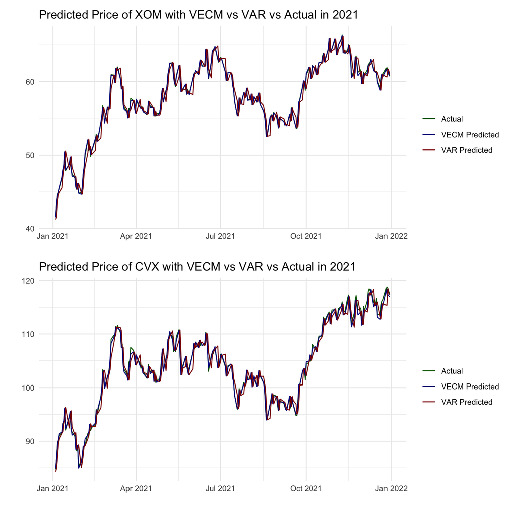

```r
(future_data[9:nrow(future_data),] %>%
  cbind(XOM_pre = VECM_pred_tsDyn[,"XOM"], XOM_pre_VAR = var.pred$XOM_pre) %>%
  ggplot(aes(x = date)) +
    geom_line(aes(y = XOM, color = "Actual")) +
    geom_line(aes(y = XOM_pre, color = "VECM Predicted")) +
    geom_line(aes(y = XOM_pre_VAR, color = "VAR Predicted")) +
    scale_color_manual("",
                       breaks = c("Actual","VECM Predicted", "VAR Predicted"),
                       values = c("darkgreen","darkblue", "darkred")) +
    theme_minimal() +
    labs(title = "Predicted Price of XOM with VECM vs VAR vs Actual in 2021", x = "", y = "")) /
  (future_data[9:nrow(future_data),] %>%
  cbind(CVX_pre = VECM_pred_tsDyn[,"CVX"], CVX_pre_VAR = var.pred$CVX_pre) %>%
  ggplot(aes(x = date)) +
    geom_line(aes(y = CVX, color = "Actual")) +
    geom_line(aes(y = CVX_pre, color = "VECM Predicted")) +
    geom_line(aes(y = CVX_pre_VAR, color = "VAR Predicted")) +
    scale_color_manual("",
                       breaks = c("Actual","VECM Predicted", "VAR Predicted"),
                       values = c("darkgreen","darkblue", "darkred")) +
    theme_minimal() +
    labs(title = "Predicted Price of CVX with VECM vs VAR vs Actual in 2021", x = "", y = ""))
```

We evaluate the performance of predictive model by out-of-sample RMSE.

```r
data.frame(
  RMSE = c("CVX","XOM"),
  VAR = c(rmse(future_data[9:nrow(future_data),]$XOM, var.pred$XOM_pre),
          rmse(future_data[9:nrow(future_data),]$CVX, var.pred$CVX_pre)),
  VECM = c(rmse(future_data[9:nrow(future_data),]$XOM, VECM_pred_tsDyn[,"XOM"]),
           rmse(future_data[9:nrow(future_data),]$CVX, VECM_pred_tsDyn[,"CVX"]))
)
```

```
##   RMSE      VAR      VECM
## 1  CVX 1.067860 0.1542644
## 2  XOM 1.643806 0.4675979
```

We evaluate the performance of predictive model by out-of-sample R-squared (the deviation that our model is able to explain).

```r
data.frame(
  R_squared = c("CVX","XOM"),
  VAR = c(cor(future_data[9:nrow(future_data),]$XOM, var.pred$XOM_pre)^2,
          cor(future_data[9:nrow(future_data),]$CVX, var.pred$CVX_pre)^2),
  VECM = c(cor(future_data[9:nrow(future_data),]$XOM, VECM_pred_tsDyn[,"XOM"])^2,
           cor(future_data[9:nrow(future_data),]$CVX, VECM_pred_tsDyn[,"CVX"])^2)
)
```

```
##   R_squared       VAR      VECM
## 1       CVX 0.9563592 0.9991141
## 2       XOM 0.9559831 0.9972221
```

The out-of-sample R-squared of our VECM model is extremely high as well.

# Time Period

We decide to look at our data from different time periods. For comparison purposes, all of our models will be trained with 3 years of data and tested with 1 year of data following the 3 year period.

First, we trained our model with 2010-2012 data to predict the prices of 2013.

```r
VECM_2010 <- VECM(tq_get(c("CVX","XOM"), get = "stock.prices", from = "2010-01-01", to = "2012-12-31") %>% dplyr::select(symbol, date, close) %>%
                    mutate(close = round(close, 2)) %>% pivot_wider(names_from = symbol, values_from = close) %>% dplyr::select(CVX, XOM),
                  lag = 8, r = 1, estim = "2OLS", LRinclude = "const", exogen = NULL)
summary(VECM_2010)
```

```
## #############
## ###Model VECM
## #############
## Full sample size: 753    End sample size: 744
## Number of variables: 2   Number of estimated slope parameters 34
## AIC -542.0465    BIC -380.625    SSR 1968.434
## Cointegrating vector (estimated by 2OLS):
##    CVX       XOM    const
## r1   1 -1.325234 6.633403
##
##
##              ECT                 CVX -1              XOM -1
## Equation CVX -0.0143(0.0133)     -0.0373(0.0692)     0.0884(0.0986)
## Equation XOM 0.0065(0.0094)      -0.0038(0.0485)     -0.0050(0.0691)
##              CVX -2             XOM -2              CVX -3
## Equation CVX 0.0392(0.0692)     -0.0065(0.0987)     0.0241(0.0692)
## Equation XOM 0.0062(0.0484)     0.0102(0.0691)      0.0036(0.0485)
##              XOM -3              CVX -4              XOM -4
## Equation CVX -0.1547(0.0987)     -0.0379(0.0692)     0.1459(0.0985)
## Equation XOM -0.0773(0.0691)     -0.0351(0.0485)     0.1137(0.0690).
##              CVX -5              XOM -5              CVX -6
## Equation CVX -0.0721(0.0693)     -0.0648(0.0990)     -0.0871(0.0692)
## Equation XOM -0.0521(0.0485)     -0.0698(0.0694)     -0.0852(0.0485).
##              XOM -6            CVX -7              XOM -7
## Equation CVX 0.1678(0.0991).   0.0259(0.0695)      0.0183(0.0996)
## Equation XOM 0.1506(0.0694)*   -0.0305(0.0487)     0.0739(0.0697)
##              CVX -8              XOM -8
## Equation CVX 0.0036(0.0694)      -0.0461(0.0995)
## Equation XOM -0.0563(0.0486)     0.0114(0.0697)
```

```r
future_data_2013 <- tq_get(c("CVX","XOM"), get = "stock.prices", from = "2012-12-19", to = "2013-12-31") %>%
  dplyr::select(symbol, date, close) %>%
  mutate(close = round(close, 2)) %>%
  pivot_wider(names_from = symbol, values_from = close)

VECM_pred_2013 <- data.frame(CVX = NA, XOM = NA)
for (i in 1:(nrow(future_data_2013)-8)) {
  VECM_pred_2013[i,"CVX"] <- predict(VECM_2010, newdata = future_data_2013[i:(i+8),c("CVX","XOM")], exoPred = NULL, n.ahead=1)[1]
  VECM_pred_2013[i,"XOM"] <- predict(VECM_2010, newdata = future_data_2013[i:(i+8),c("CVX","XOM")], exoPred = NULL, n.ahead=1)[2]
}
```

Then, we trained our model with 2014-2016 data to predict the prices of 2017.

```r
VECM_2014 <- VECM(tq_get(c("XOM", "CVX"), get = "stock.prices", from = "2014-01-01", to = "2016-12-31") %>% dplyr::select(symbol, date, close) %>%
                    mutate(close = round(close, 2)) %>% pivot_wider(names_from = symbol, values_from = close) %>% dplyr::select(CVX, XOM),
                  lag = 8, r = 1, estim = "2OLS", LRinclude = "const", exogen = NULL)
summary(VECM_2014)
```

```
## #############
## ###Model VECM
## #############
## Full sample size: 756    End sample size: 747
## Number of variables: 2   Number of estimated slope parameters 34
## AIC -131.8251    BIC 29.73723    SSR 2312.422
## Cointegrating vector (estimated by 2OLS):
##    CVX       XOM    const
## r1   1 -1.707813 46.02396
##
##
##              ECT                 CVX -1             XOM -1
## Equation CVX -0.0082(0.0135)     0.0183(0.0627)     -0.0285(0.0862)
## Equation XOM 0.0098(0.0099)      0.0229(0.0459)     -0.0533(0.0631)
##              CVX -2              XOM -2              CVX -3
## Equation CVX 0.0194(0.0626)      0.0265(0.0861)      -0.0230(0.0621)
## Equation XOM -0.0011(0.0459)     -0.0066(0.0631)     -0.0054(0.0455)
##              XOM -3              CVX -4             XOM -4
## Equation CVX -0.0328(0.0854)     0.0092(0.0621)     -0.1208(0.0853)
## Equation XOM -0.0408(0.0626)     0.0516(0.0455)     -0.1452(0.0625)*
##              CVX -5              XOM -5              CVX -6
## Equation CVX 0.0205(0.0620)      -0.0612(0.0852)     0.1346(0.0619)*
## Equation XOM -0.0028(0.0454)     -0.0152(0.0624)     0.0884(0.0454).
##              XOM -6             CVX -7             XOM -7
## Equation CVX -0.1426(0.0850).   0.0056(0.0618)     -0.0528(0.0849)
## Equation XOM -0.1097(0.0623).   0.0085(0.0453)     -0.0227(0.0622)
##              CVX -8              XOM -8
## Equation CVX -0.0637(0.0617)     0.0528(0.0846)
## Equation XOM -0.0194(0.0452)     0.0419(0.0620)
```

```r
future_data_2017 <- tq_get(c("CVX","XOM"), get = "stock.prices", from = "2016-12-20", to = "2017-12-31") %>%
  dplyr::select(symbol, date, close) %>%
  mutate(close = round(close, 2)) %>%
  pivot_wider(names_from = symbol, values_from = close)

VECM_pred_2017 <- data.frame(CVX = NA, XOM = NA)
for (i in 1:(nrow(future_data_2017)-8)) {
  VECM_pred_2017[i,"CVX"] <- predict(VECM_2014, newdata = future_data_2017[i:(i+8),c("CVX","XOM")], exoPred = NULL, n.ahead=1)[1]
  VECM_pred_2017[i,"XOM"] <- predict(VECM_2014, newdata = future_data_2017[i:(i+8),c("CVX","XOM")], exoPred = NULL, n.ahead=1)[2]
}
```

```r
data.frame(
  VECM = c("CVX","XOM"),
  Year2013 = c(rmse(future_data_2013[9:nrow(future_data_2013),]$CVX, VECM_pred_2013[,"CVX"]),
               rmse(future_data_2013[9:nrow(future_data_2013),]$XOM, VECM_pred_2013[,"XOM"])),
  Year2017 = c(rmse(future_data_2017[9:nrow(future_data_2017),]$CVX, VECM_pred_2017[,"CVX"]),
               rmse(future_data_2017[9:nrow(future_data_2017),]$XOM, VECM_pred_2017[,"XOM"])),
  Year2021 = c(rmse(future_data[9:nrow(future_data),]$XOM, VECM_pred_tsDyn[,"XOM"]),
               rmse(future_data[9:nrow(future_data),]$CVX, VECM_pred_tsDyn[,"CVX"]))
)
```

```
##   VECM  Year2013  Year2017  Year2021
## 1  CVX 0.2491846 0.2030722 0.1542644
## 2  XOM 0.1873294 0.2237042 0.4675979
```

We can see that however, our prediction is despite being quite accurate, are prone to time period changes.

# Leader Analysis

```r
energy_stocks <- c("^GSPE","APA","BKR","COP","CTRA","CVX","DVN","EOG","FANG","HAL","HES","KMI","MPC","MRO","OKE","OXY","PSX","PXD","SLB",
                   "VLO","WMB","XOM")

data <- tq_get(energy_stocks, get = "stock.prices", from = "2013-01-01", to = "2021-12-31") %>%
  dplyr::select(symbol, date, close) %>%
  mutate(close = round(close, 2)) %>%
  pivot_wider(names_from = symbol, values_from = close) %>%
  dplyr::select(-date)

head(data)
```

```
## # A tibble: 6 × 22
##   `^GSPE`   APA   BKR   COP  CTRA   CVX   DVN   EOG  FANG   HAL   HES   KMI
##     <dbl> <dbl> <dbl> <dbl> <dbl> <dbl> <dbl> <dbl> <dbl> <dbl> <dbl> <dbl>
## 1    545.  80.7  42.1  59.2  24.6  110.  52.5  61.8  19.2  35.7  53.7  36.5
## 2    545.  81.8  42.6  59.2  24.9  110.  53.4  62.1  19.1  36.3  54.2  37.0
## 3    551.  83.2  43.5  59.8  25.1  110.  54.6  62.9  20.0  36.6  55.0  36.7
## 4    546.  80.4  43.0  59.2  24.9  110.  54.6  63.0  20.8  36.6  55.8  37.3
## 5    545.  79.9  42.4  58.4  24.5  109.  54.2  62.1  20.6  36.2  55.4  37.3
## 6    544.  79.6  42.4  58.2  23.8  110.  53.4  62.3  20.5  36.5  55.6  37.1
## # … with 10 more variables: MPC <dbl>, MRO <dbl>, OKE <dbl>, OXY <dbl>,
## #   PSX <dbl>, PXD <dbl>, SLB <dbl>, VLO <dbl>, WMB <dbl>, XOM <dbl>
```

The one shown are the leaders.

```r
leader_analysis <- as.data.frame(matrix(nrow = length(data), ncol = length(data), dimnames = list(colnames(data),colnames(data))))

for (i in 1:length(data)) {
  for (j in 1:length(data)) {
    if (j > i) {
      temp_data <- as.matrix(cbind(data[,i],data[,j]))
      temp_model <- summary(VECM(temp_data, lag = 8, r = 1, estim = "2OLS", LRinclude = "const", exogen = NULL))

      if (sum(!grepl("\\*", temp_model$bigcoefficients[,1])) == 0) {
        leader_analysis[i,j] <- "Both"
      } else if (sum(!grepl("\\*", temp_model$bigcoefficients[,1])) == 1) {
        leader_analysis[i,j] <- colnames(temp_model$model)[1:2][!grepl("\\*", temp_model$bigcoefficients[,1])]
      } else {
        leader_analysis[i,j] <- NA
      }
    } else if (j == i) {
      leader_analysis[i,j] <- 1
    }
  }
}

leader_analysis
```

```
##       ^GSPE  APA BKR COP CTRA CVX  DVN  EOG FANG  HAL  HES  KMI  MPC  MRO OKE
## ^GSPE     1  APA  NA  NA CTRA  NA <NA> <NA> <NA> <NA> <NA> <NA> <NA> <NA>  NA
## APA      NA    1  NA  NA  APA  NA <NA> <NA> <NA> <NA> <NA> <NA> <NA> <NA>  NA
## BKR      NA <NA>   1  NA CTRA  NA <NA> <NA> <NA> <NA> <NA> <NA> <NA> <NA>  NA
## COP      NA <NA>  NA   1 CTRA  NA  DVN <NA> FANG Both <NA> <NA> <NA>  MRO  NA
## CTRA     NA <NA>  NA  NA    1  NA CTRA <NA> FANG CTRA <NA>  KMI  MPC  MRO  NA
## CVX      NA <NA>  NA  NA <NA>   1  DVN  EOG FANG  HAL <NA>  KMI  MPC  MRO  NA
## DVN      NA <NA>  NA  NA <NA>  NA    1 <NA> <NA> <NA> <NA> <NA> <NA> <NA>  NA
## EOG      NA <NA>  NA  NA <NA>  NA <NA>    1 <NA> Both <NA>  KMI <NA>  MRO  NA
## FANG     NA <NA>  NA  NA <NA>  NA <NA> <NA>    1 Both  HES  KMI <NA>  MRO  NA
## HAL      NA <NA>  NA  NA <NA>  NA <NA> <NA> <NA>    1 <NA> <NA> <NA> <NA>  NA
## HES      NA <NA>  NA  NA <NA>  NA <NA> <NA> <NA> <NA>    1  KMI  MPC  MRO  NA
## KMI      NA <NA>  NA  NA <NA>  NA <NA> <NA> <NA> <NA> <NA>    1 <NA>  MRO  NA
## MPC      NA <NA>  NA  NA <NA>  NA <NA> <NA> <NA> <NA> <NA> <NA>    1  MRO  NA
## MRO      NA <NA>  NA  NA <NA>  NA <NA> <NA> <NA> <NA> <NA> <NA> <NA>    1  NA
## OKE      NA <NA>  NA  NA <NA>  NA <NA> <NA> <NA> <NA> <NA> <NA> <NA> <NA>   1
## OXY      NA <NA>  NA  NA <NA>  NA <NA> <NA> <NA> <NA> <NA> <NA> <NA> <NA>  NA
## PSX      NA <NA>  NA  NA <NA>  NA <NA> <NA> <NA> <NA> <NA> <NA> <NA> <NA>  NA
## PXD      NA <NA>  NA  NA <NA>  NA <NA> <NA> <NA> <NA> <NA> <NA> <NA> <NA>  NA
## SLB      NA <NA>  NA  NA <NA>  NA <NA> <NA> <NA> <NA> <NA> <NA> <NA> <NA>  NA
## VLO      NA <NA>  NA  NA <NA>  NA <NA> <NA> <NA> <NA> <NA> <NA> <NA> <NA>  NA
## WMB      NA <NA>  NA  NA <NA>  NA <NA> <NA> <NA> <NA> <NA> <NA> <NA> <NA>  NA
## XOM      NA <NA>  NA  NA <NA>  NA <NA> <NA> <NA> <NA> <NA> <NA> <NA> <NA>  NA
##        OXY  PSX  PXD  SLB  VLO  WMB  XOM
## ^GSPE  OXY <NA> <NA> <NA> <NA> <NA> <NA>
## APA   <NA> <NA> <NA> <NA>  VLO  APA <NA>
## BKR   <NA> <NA> <NA> <NA>  VLO <NA> <NA>
## COP   <NA> <NA>  PXD <NA>  VLO <NA> <NA>
## CTRA  <NA>  PSX <NA> <NA>  VLO CTRA <NA>
## CVX    OXY  PSX  PXD  SLB  VLO  WMB Both
## DVN   <NA> <NA> <NA> <NA>  VLO  DVN <NA>
## EOG    OXY <NA>  PXD Both <NA> <NA>  XOM
## FANG   OXY <NA> <NA> Both <NA>  WMB  XOM
## HAL   <NA> <NA> <NA> <NA> <NA> <NA> <NA>
## HES    OXY Both <NA>  SLB Both <NA>  XOM
## KMI   <NA> <NA> <NA> <NA>  VLO  KMI <NA>
## MPC    OXY <NA>  PXD Both <NA> Both  XOM
## MRO   <NA> <NA> <NA> <NA> <NA>  MRO <NA>
## OKE   Both  PSX  PXD Both  VLO  WMB Both
## OXY      1 <NA> <NA> <NA> <NA> <NA>  OXY
## PSX   <NA>    1  PXD Both  VLO Both  XOM
## PXD   <NA> <NA>    1  SLB  VLO <NA>  XOM
## SLB   <NA> <NA> <NA>    1 <NA> <NA> <NA>
## VLO   <NA> <NA> <NA> <NA>    1 Both  XOM
## WMB   <NA> <NA> <NA> <NA> <NA>    1  XOM
## XOM   <NA> <NA> <NA> <NA> <NA> <NA>    1
```